# R Learner and Integrative R Learner on NSW Data

# 3 Integrative R-Learner

## 3.1 Reload data to reset

```r
set.seed(123)
```

```r
nsw_experimental <- read.csv(experimental_path)
```

```r
nsw_observational <- read.csv(observational_path)
```

## 3.2 Combine Data

Row bind the data and create an indicator variable (1 = experimental, 0 = observational)

```r
nsw_experimental$S <- 1
nsw_observational$S <- 0

data_all <- rbind(nsw_experimental, nsw_observational)
```

## 3.3 Define Outcome, Covariates, Assignment, and Origin

```r
Y <- data_all$re78
A <- data_all$treat

X <- data_all[, c("age","educ","black","hisp","marr","nodegree","re74","re75")]
S <- data_all$S
```

## 3.4 Calculate Propensity Score

```r
if (use_k_fold == FALSE){
  prop_model <- glm(
    S ~ .,
    data = data_all[, c("S", "age","educ","black","hisp","marr","nodegree","re74","re75")],
    family = binomial()
  )

  e_hat <- predict(
    prop_model,
    newdata = data_all[, c("age","educ","black","hisp","marr","nodegree","re74","re75")],
    type = "response"
  )
}
```

```r
if (use_k_fold == TRUE){
  n <- nrow(data_all)
  K <- 5

  fold_id <- sample(rep(1:K, length.out = n))

  e_hat <- rep(NA, n)

  features <- c("age","educ","black","hisp","marr","nodegree","re74","re75")

  for (k in 1:K) {

    train_idx <- which(fold_id != k)
    test_idx  <- which(fold_id == k)

    train_data <- data_all[train_idx, c("S", features)]
    test_data  <- data_all[test_idx, features]

    # fit model on training fold
    prop_model_k <- glm(
      S ~ .,
      data = train_data,
      family = binomial()
    )

    # predict on held-out fold
    e_hat[test_idx] <- predict(
      prop_model_k,
      newdata = test_data,
      type = "response"
    )
  }
}
```

### 3.4.1 Check Overlap

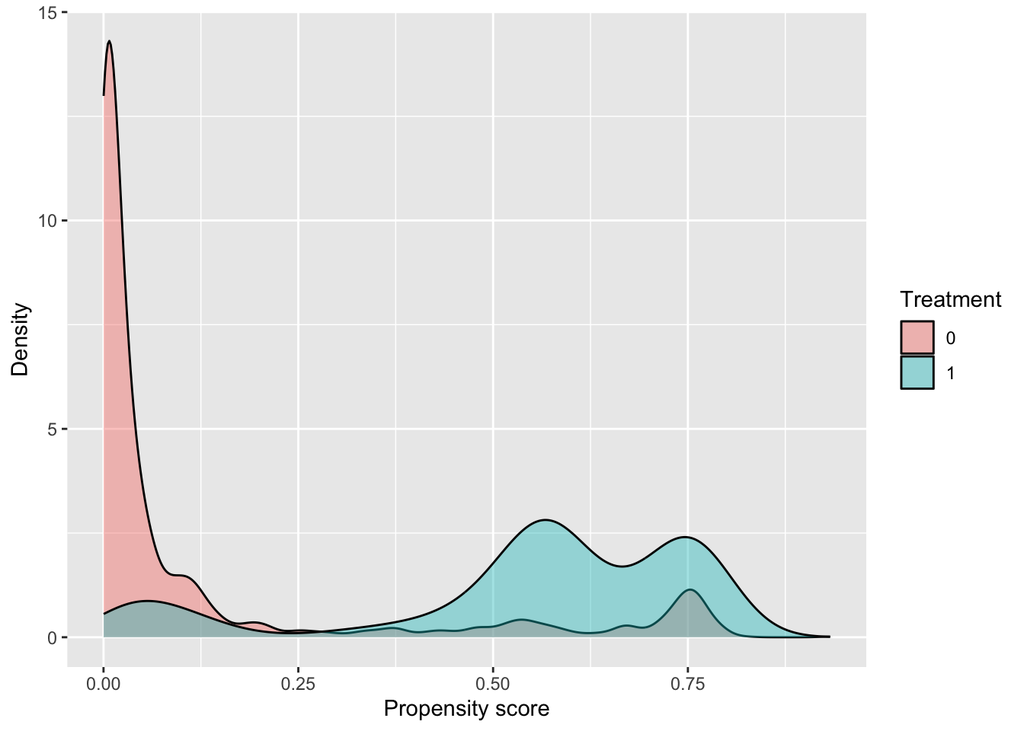

```r
df <- data.frame(
  ps = e_hat,
  treat = data_all$treat
)

ggplot(df, aes(x = ps, fill = factor(treat))) +
  geom_density(alpha = 0.4) +
  labs(fill = "Treatment", x = "Propensity score", y = "Density")
```

Wow, look at that overlap. Even with the truth mixed in, we still have this mass on the left for control units

## 3.5 Calculate Outcome Model

```r
if (use_k_fold == FALSE) {
  # RCT outcome model
  mu_rct_model <- lm(re78 ~ age + educ + black + hisp + marr + nodegree + re74 + re75,
                     data = nsw_experimental)

  # Observational outcome model
  mu_obs_model <- lm(re78 ~ age + educ + black + hisp + marr + nodegree + re74 + re75,
                     data = nsw_observational)

  X_rct <- X[S == 1, ]
  X_obs <- X[S == 0, ]

  mu_hat <- numeric(nrow(X))

  mu_hat[S == 1] <- predict(mu_rct_model, newdata = X_rct)
  mu_hat[S == 0] <- predict(mu_obs_model, newdata = X_obs)
}
```

```r
if (use_k_fold == TRUE){
  K <- 5

  mu_hat <- numeric(nrow(X))

  # -------------------------
  # RCT folds
  # -------------------------
  rct_idx <- which(S == 1)

  folds_rct <- createFolds(rct_idx, k = K, list = TRUE)

  for (k in 1:K) {

    test_idx <- rct_idx[folds_rct[[k]]]
    train_idx <- setdiff(rct_idx, test_idx)

    fit <- lm(
      re78 ~ age + educ + black + hisp + marr + nodegree + re74 + re75,
      data = data.frame(
        re78 = Y[train_idx],
        X[train_idx, ]
      )
    )

    mu_hat[test_idx] <- predict(
      fit,
      newdata = X[test_idx, ]
    )
  }

  # -------------------------
  # Observational folds
  # -------------------------
  obs_idx <- which(S == 0)

  folds_obs <- createFolds(obs_idx, k = K, list = TRUE)

  for (k in 1:K) {

    test_idx <- obs_idx[folds_obs[[k]]]
    train_idx <- setdiff(obs_idx, test_idx)

    fit <- lm(
      re78 ~ age + educ + black + hisp + marr + nodegree + re74 + re75,
      data = data.frame(
        re78 = Y[train_idx],
        X[train_idx, ]
      )
    )

    mu_hat[test_idx] <- predict(
      fit,
      newdata = X[test_idx, ]
    )
  }
}
```

## 3.6 Initial Confounding Function

This could be any value, but to have a smart initialization, we use the difference in outcomes between observed and RCT

```r
# RCT outcome model
mu_rct_model <- lm(re78 ~ age + educ + black + hisp + marr + nodegree + re74 + re75,
                   data = nsw_experimental)

# Observational outcome model
mu_obs_model <- lm(re78 ~ age + educ + black + hisp + marr + nodegree + re74 + re75,
                   data = nsw_observational)

mu_rct_pred <- predict(mu_rct_model, newdata = X)
mu_obs_pred <- predict(mu_obs_model, newdata = X)

c_hat <- mu_obs_pred - mu_rct_pred
```

## 3.7 Fit Tau using Weighted Forests

This is taken directly from the appendix algorithm 2

```r
eps_Y <- Y - mu_hat
eps_A <- A - e_hat
weights <- eps_A^2
```

Weighted Forest Regression, weights give us a signal of how much an observation can give us a heterogenous effect

```r
for (b in 1:4) {

  Y_tilde <- (eps_Y / eps_A) - (1 - S) * c_hat

  tau_forest <- regression_forest(
    X,
    Y_tilde,
    sample.weights = weights
  )

  tau_hat <- predict(tau_forest, X)$predictions


  Y_tilde <- (eps_Y / eps_A) - tau_hat

  obs_idx <- which(S == 0)

  c_forest <- regression_forest(
    X[obs_idx,],
    Y_tilde[obs_idx],
    sample.weights = weights[obs_idx]
  )

  c_hat <- predict(c_forest, X)$predictions
}
```

```r
obs_idx <- which(S == 0)
tau_hat <- predict(tau_forest, X)$predictions
tau_hat_obs <- tau_hat[obs_idx]
```

We only want to see the ATE for the observational data

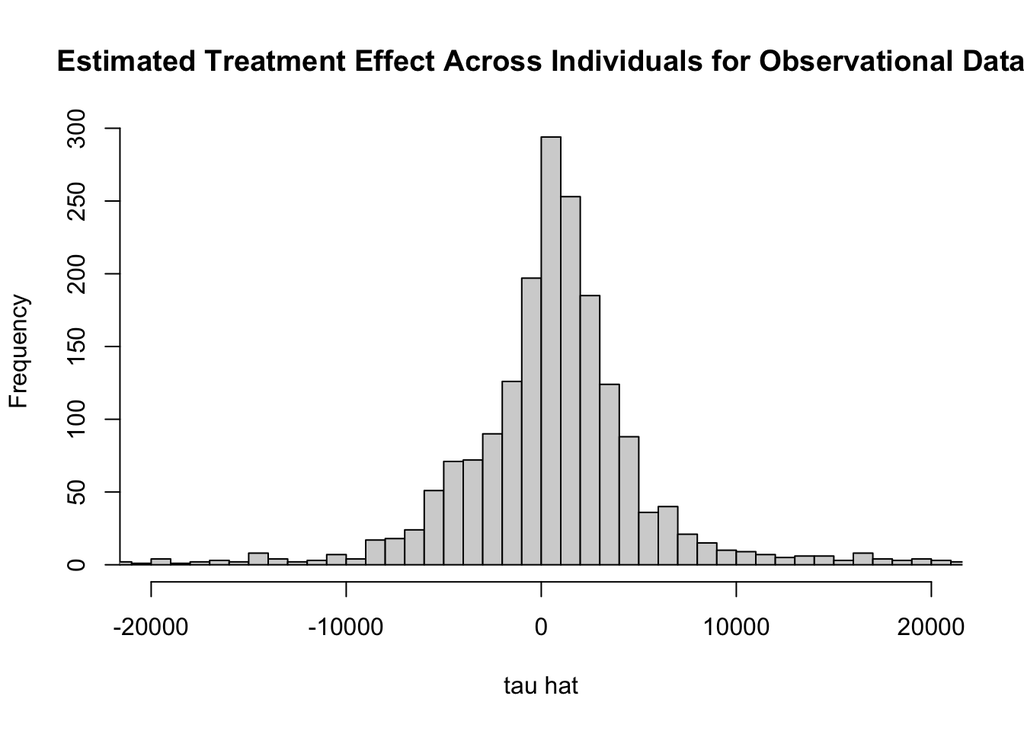

```r
hist(
  tau_hat_obs,
  xlab = "tau hat",
  main = "Estimated Treatment Effect Across Individuals for Observational Data",
  breaks = 300,
  xlim = c(-20000, 20000)
)
```

Get ATE

```r
ate <- mean(tau_hat_obs)  # or all X, but no weights
ate
```

```
[1] 862.2943
```

```r
ate_se <- sd(tau_hat) / sqrt(length(tau_hat))
ate_se
```

```
[1] 146.1605
```

# 4 Final Results

```r
# Values you already have
ate_int  <- 862.2943
se_int   <- 146.1605

ate_rct  <- 1695.154
se_rct   <- 67.43434

ate_obs  <- -2243.241
se_obs   <- 118.0976

# Create table
results <- data.frame(
  Method = c("Integrative R-Learner", "R-Learner (RCT)", "R-Learner (Obs)"),
  ATE = c(ate_int, ate_rct, ate_obs),
  SE = c(se_int, se_rct, se_obs)
)

# 95% CI (Wald)
z <- 1.96
results$CI_lower <- results$ATE - z * results$SE
results$CI_upper <- results$ATE + z * results$SE

kable(results, digits = 3, caption = "ATE Estimates with 95% Confidence Intervals")
```

ATE Estimates with 95% Confidence Intervals

| Method | ATE | SE | CI_lower | CI_upper |
| --- | --- | --- | --- | --- |
| Integrative R-Learner | 862.294 | 146.161 | 575.820 | 1148.769 |
| R-Learner (RCT) | 1695.154 | 67.434 | 1562.983 | 1827.325 |
| R-Learner (Obs) | -2243.241 | 118.098 | -2474.712 | -2011.770 |

The integrative R-Learner ATE was estimated only using observational data, we get a very confident positive ATE using Integrative R-Learner. The R-Learner using only observational data yields a negative ATE which does not reflect the RCT ATE. This suggests that the Integrative R-Learner outperforms R-Learner, but we would need access to an experimental and observational dataset.